# ‘A quantitative analysis using feature engineering to train and predict AI models using Machine learning’

M.D’Arcy 40302488

13/03/2022

## Introduction

This report guides the reader through the process of understanding AI and Machine learning. Today more and more industry related business are using AI to improve their daily work load. From using it to aid statistical analysis to training a model to caption what is in an image, Machine Learning certainly has cemented its purpose in an industry wide work.

Throughout my report, I will explore the creation of a portable bitmap image dataset from handwritten letters,faces,and exclamation marks, performance of feature engineering, a statistical analysis and finally the implentation of a machine learning model.All code is written in R through R studio

## Section 1

————— DataSet —————

The project uses a dataset comprised of 140 individual images, these break down into 20 smiley face, 20 sad face, 20 exclamation mark and letters a -j with 8 of each. The symbols are created using gimp specifically contained in an 18x18 grid. Each set has their own criteria to ensure a base standard;

each face consists of two eyes, a nose and a mouth, each symbol has to be in an upright position,and must possess a style of “handwritten”.

————— Creation of dataset —————

The 140 files were exported as portable bitmap format (PGM), type ASCII. Once finished, I open the dataset in R Studio and read in the list of files and loop through them. Skipping the first four lines of the PGM file header and added the values iteratively to a matrix. To analyse the images we turn each one into a comma delimited file, any pixel value >128 is represented using a 1 and <128 is 0. Using this a matrix is created and stored in a .csv file.A for loop is created to circle through all 140 images.

## Section 2

—————Introduction—————

In Section 2 we explore feature engineering,where we examine different aspects which could aid in the identification of our images. This array of characteristics describes the image,with 16 features in total. We define a pixel as having 8 neighbors, and create a matrix first from our csv files.

We create identifiers for the images using index and for the features using labels. I read a single CSV file and created a new test matrix with the same dimensions from section one. However, this time they needed transposed once or twice before the shape of the image normalized and I could run the various calculations on it. Once I had a functional matrix, I started from feature one.

—————Feature 1 —————

We created a function called “nr_pix” which measures the number of black pixels in the image.

—————Feature 2-5 —————

We build on the function “nr_pix” using it for functions “rows_with_1”, “cols_with_1”,“rows_with_3p” and “cols_with3p” which measures the number of black pixels in rows and columns specifically 1 and 3 or more pixels respectively. I made use of built in features such as sum,col sum, and row sum to have both ease of understanding and a documentated function. The first five features have small chamhges in the pattern but is simliar in caluculations.

————— Feature 6—————

Following on, we examine aspect ratio which is The vertical distance, in pixels, between the topmost and bottommost black pixels in the image which are measured from the pixel centre called the height. The horizontal distance, in pixels, between the leftmost and rightmost black pixels in the image measured from the pixel centre called width.I again made use of R built-in function this time using the which, min and max functions to iteratively search thorough the columns or row depending on if I was calculating height or width. I .This feature is width/height.

—————Feature 7-14 —————

The next 7 features examine the neighbors of the pixel,following on similarly from how we first created “nr_pix” we first create “neigh_1” which is the number of black pixels with only 1 corresponding pixel in the 8 tiles around it. From this we take each the next features and explore its pixels neighbours shown in the diagram where the green represent pixel spaces without a black pixel present.

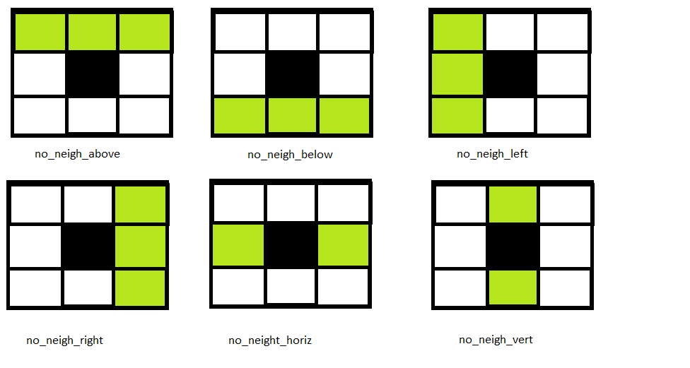

We used a counter to count the number of times a specific pattern was seen within a given matrix. We then created a nested for loop that would search through rows and columns using the index of for nested loop and incrementing by one to depending on the pattern. This was all wrote within a single if statement and printed the counter at the end of the loop

Most important thing was when I was tracing my code.I wanted to able to reuse my code and have less confusing code,which is where I impleneted y vertical and horizontal functions.

————— Feature 15-16 —————

The last two features involve the use of the clump and raster libraries where we examine “eyes” and “connected_areas” both functions where a region of white space is enclosed with black pixels.

I encountered difficulty both understanding the raster and clump libraries, and transforming my information into a usable function. The program was returning -inf until I released I needed to create a new matrix to invert it to.

—————Custom Features ————— For my custom features I examined different structures of matrices. I first thought that an inclusion of upper and lower triangular matrices would help in identification of curves present in “a”,“b” and smiley faces,

However, I could only hard-code the matrix and was only identified a handful of times in further look into the features.csv. I abandoned these features and pursued a separate type of matrix analysis called “stocastic matrix”, Which examines all the pixels in the matrices and then returns the probability of a black pixel present. From this I wanted to link the connected areas aspect and use it as a feature. Further analysis occurs in section 3.

—————Creation of Features CSV —————

Once the code had been tested, a function was created to could call them iteratively inside a for loop which I used to create the final feature csv

The data collected from our 16 features is stored in Features.csv using the write table function.

—————Reflection —————

For this section I had difficulty visualizing the neighbor pixels and the concept of why we needed each function. It wasn’t until section 3 that I understood through the statistical analysis the importance of each feature. Upon discussion with classmates about section 2 it appeared that many choose not to write it as functions. For my code personally I prefer to use functions as it allows me to return and test each feature individually. I then called each function with the matrix, where each function has a row matching 1 of the 140 images each. I then used the bind function to add column titles and exported to the csv. Both the data frame and csv is useful for section 3 analysis.

## Section 3 Introduction

Section 3 of our report dives into the Statistical analysis of feature data. To explore which features are important for distinguishing between our handwritten symbol images we perform descriptive statistics, hypothesis testing and represent the results in visualizations. Further to this analysis,an interesting comparison between 1 pixel and 3 pixels or more with both rows and columns respectively would be interesting to confirm the possibilities set out above in our figure captions.Another graphical represenation of the above histograms is exploring them as qq plots which is a plot of the quantiles of the first data set against the quantiles of the second data set. A 45-degree reference line is also plotted. If the two sets come from a population with the same distribution, the points should fall approximately along this reference line. The more points clung to the line the closer it is to a normal distrubtion.